# STA 141B Assignment 4

Due **Feb 22, 2019** by 11:59pm. Submit by editing this file, committing the changes with git, and then pushing to your private GitHub repo for the assignment. This assignment will be graded according to the class rubric.

Please do not rename this file or delete the exercise cells, because it will interfere with our grading tools. Put your answers in new cells after each exercise. You can make as many new cells as you like. Use code cells for code and Markdown cells for text. Answer all questions with complete sentences.

The purpose of this assignment is to practice scraping data from web pages.

## The San Francisco Chronicle

In this assignment, you'll scrape text from [The San Francisco Chronicle](https://www.sfchronicle.com/) newspaper and then analyze the text.

The Chronicle is organized by category into article lists. For example, there's a [Local](https://www.sfchronicle.com/local/) list, [Sports](https://www.sfchronicle.com/sports/) list, and [Food](https://www.sfchronicle.com/food/) list.

The goal of exercises 1.1 - 1.3 is to scrape articles from the Chronicle for analysis in exercise 1.4.

**Exercise 1.1.** Write a function that extracts all of the links to articles in a Chronicle article list. The function should:

- Have a parameter `url` for the URL of the article list.
- Return a list of article URLs (each URL should be a string).

Test your function on 2-3 different categories to make sure it works.

Hints:

- Be polite and save time by setting up [requests_cache](https://pypi.python.org/pypi/requests-cache) before you write your function.
- You can use any of the XML/HTML parsing packages mentioned in class. Choose one and use it throughout the entire assignment.

```python
import requests
import json
import numpy as np
import pandas as pd
import lxml.html as lx

def get_artical(page):
    response = requests.get(page)
    response.raise_for_status()
    html = lx.fromstring(response.text)
    urls=pd.DataFrame(html.xpath("//*[@id='content']//a/@href"))##get the urls and save as dataframe
    is_art =urls[0].str.contains("article")##select the links that lead to articals
    return page+urls[is_art]##return the page url+ sub url
```

```python
art=get_artical("https://www.sfchronicle.com/")
art3=get_artical("https://www.sfchronicle.com/business/")
art2=get_artical("https://www.sfchronicle.com/sports/")
```

```python
art##example
```

|  | 0 |
| --- | --- |
| 0 | https://www.sfchronicle.com//bayarea/article/C... |
| 1 | https://www.sfchronicle.com//bayarea/article/C... |
| 2 | https://www.sfchronicle.com//bayarea/article/C... |
| 4 | https://www.sfchronicle.com//bayarea/article/H... |
| 5 | https://www.sfchronicle.com//nation/article/Pr... |
| 6 | https://www.sfchronicle.com//education/article... |
| 7 | https://www.sfchronicle.com//bayarea/article/P... |
| 8 | https://www.sfchronicle.com//bayarea/article/R... |
| 9 | https://www.sfchronicle.com//outdoors/stienstr... |
| 10 | https://www.sfchronicle.com//crime/article/Arm... |
| 11 | https://www.sfchronicle.com//bayarea/article/O... |
| 12 | https://www.sfchronicle.com//crime/article/The... |
| 13 | https://www.sfchronicle.com//sharks/article/Jo... |
| 14 | https://www.sfchronicle.com//giants/article/Gi... |
| 15 | https://www.sfchronicle.com//giants/article/Gi... |
| 18 | https://www.sfchronicle.com//49ers/article/49e... |
| 19 | https://www.sfchronicle.com//49ers/article/49e... |
| 20 | https://www.sfchronicle.com//bayarea/article/T... |
| 21 | https://www.sfchronicle.com//bayarea/article/T... |
| 22 | https://www.sfchronicle.com//49ers/article/Wil... |
| 23 | https://www.sfchronicle.com//49ers/article/Wil... |
| 24 | https://www.sfchronicle.com//politics/article/... |
| 25 | https://www.sfchronicle.com//politics/article/... |
| 26 | https://www.sfchronicle.com//politics/article/... |
| 27 | https://www.sfchronicle.com//politics/article/... |
| 28 | https://www.sfchronicle.com//sports/ostler/art... |
| 29 | https://www.sfchronicle.com//sports/ostler/art... |
| 30 | https://www.sfchronicle.com//bayarea/otisrtayl... |
| 31 | https://www.sfchronicle.com//bayarea/otisrtayl... |
| 32 | https://www.sfchronicle.com//bayarea/willieswo... |
| ... | ... |
| 110 | https://www.sfchronicle.com//style/article/Asi... |
| 111 | https://www.sfchronicle.com//style/article/Asi... |
| 115 | https://www.sfchronicle.com//chronicle_vault/a... |
| 116 | https://www.sfchronicle.com//chronicle_vault/a... |
| 124 | https://www.sfchronicle.com//news/article/San-... |
| 125 | https://www.sfchronicle.com//news/article/San-... |
| 126 | https://www.sfchronicle.com//49ers/article/Wil... |
| 127 | https://www.sfchronicle.com//49ers/article/Wil... |
| 128 | https://www.sfchronicle.com//politics/article/... |
| 129 | https://www.sfchronicle.com//politics/article/... |
| 130 | https://www.sfchronicle.com//politics/article/... |
| 131 | https://www.sfchronicle.com//politics/article/... |
| 132 | https://www.sfchronicle.com//sports/ostler/art... |
| 133 | https://www.sfchronicle.com//sports/ostler/art... |
| 134 | https://www.sfchronicle.com//bayarea/otisrtayl... |
| 135 | https://www.sfchronicle.com//bayarea/otisrtayl... |
| 136 | https://www.sfchronicle.com//bayarea/willieswo... |
| 137 | https://www.sfchronicle.com//bayarea/willieswo... |
| 138 | https://www.sfchronicle.com//crime/article/San... |
| 139 | https://www.sfchronicle.com//crime/article/San... |
| 143 | https://www.sfchronicle.com//bayarea/philmatie... |
| 145 | https://www.sfchronicle.com//business/networth... |
| 147 | https://www.sfchronicle.com//wine/article/How-... |
| 149 | https://www.sfchronicle.com//opinion/article/G... |
| 151 | https://www.sfchronicle.com//restaurants/artic... |
| 153 | https://www.sfchronicle.com//bayarea/otisrtayl... |
| 155 | https://www.sfchronicle.com//travel/article/Sn... |
| 157 | https://www.sfchronicle.com//sports/ostler/art... |
| 159 | https://www.sfchronicle.com//bayarea/nativeson... |
| 161 | https://www.sfchronicle.com//bayarea/willieswo... |

116 rows × 1 columns

```python
art2##example
```

|  | 0 |
| --- | --- |
| 0 | https://www.sfchronicle.com/sports//giants/art... |
| 1 | https://www.sfchronicle.com/sports//giants/art... |
| 2 | https://www.sfchronicle.com/sports//giants/art... |
| 4 | https://www.sfchronicle.com/sports//giants/ost... |
| 5 | https://www.sfchronicle.com/sports//sports/art... |
| 6 | https://www.sfchronicle.com/sports//sports/art... |
| 7 | https://www.sfchronicle.com/sports//sharks/art... |
| 8 | https://www.sfchronicle.com/sports//sharks/art... |
| 9 | https://www.sfchronicle.com/sports//athletics/... |
| 10 | https://www.sfchronicle.com/sports//athletics/... |
| 11 | https://www.sfchronicle.com/sports//sports/art... |
| 12 | https://www.sfchronicle.com/sports//sports/art... |
| 13 | https://www.sfchronicle.com/sports//sports/art... |
| 15 | https://www.sfchronicle.com/sports//warriors/a... |
| 16 | https://www.sfchronicle.com/sports//warriors/a... |
| 17 | https://www.sfchronicle.com/sports//warriors/a... |
| 18 | https://www.sfchronicle.com/sports//warriors/a... |
| 19 | https://www.sfchronicle.com/sports//warriors/a... |
| 20 | https://www.sfchronicle.com/sports//warriors/a... |
| 22 | https://www.sfchronicle.com/sports//athletics/... |
| 23 | https://www.sfchronicle.com/sports//athletics/... |
| 24 | https://www.sfchronicle.com/sports//athletics/... |
| 25 | https://www.sfchronicle.com/sports//athletics/... |
| 26 | https://www.sfchronicle.com/sports//athletics/... |
| 27 | https://www.sfchronicle.com/sports//athletics/... |
| 29 | https://www.sfchronicle.com/sports//giants/art... |
| 30 | https://www.sfchronicle.com/sports//giants/art... |
| 31 | https://www.sfchronicle.com/sports//giants/art... |
| 32 | https://www.sfchronicle.com/sports//giants/art... |
| 33 | https://www.sfchronicle.com/sports//giants/she... |
| ... | ... |
| 104 | https://www.sfchronicle.com/sports//sports/art... |
| 105 | https://www.sfchronicle.com/sports//giants/art... |
| 106 | https://www.sfchronicle.com/sports//travel/art... |
| 107 | https://www.sfchronicle.com/sports//outdoors/s... |
| 108 | https://www.sfchronicle.com/sports//sports/art... |
| 109 | https://www.sfchronicle.com/sports//sports/art... |
| 110 | https://www.sfchronicle.com/sports//sharks/art... |
| 111 | https://www.sfchronicle.com/sports//sharks/art... |
| 112 | https://www.sfchronicle.com/sports//athletics/... |
| 113 | https://www.sfchronicle.com/sports//athletics/... |
| 114 | https://www.sfchronicle.com/sports//sports/art... |
| 115 | https://www.sfchronicle.com/sports//sports/art... |
| 116 | https://www.sfchronicle.com/sports//sports/art... |
| 119 | https://www.sfchronicle.com/sports//sports/ann... |
| 121 | https://www.sfchronicle.com/sports//giants/ost... |
| 123 | https://www.sfchronicle.com/sports//giants/art... |
| 125 | https://www.sfchronicle.com/sports//giants/art... |
| 127 | https://www.sfchronicle.com/sports//sports/art... |
| 128 | https://www.sfchronicle.com/sports//sports/art... |
| 129 | https://www.sfchronicle.com/sports//sports/art... |
| 130 | https://www.sfchronicle.com/sports//sports/art... |
| 131 | https://www.sfchronicle.com/sports//sports/art... |
| 132 | https://www.sfchronicle.com/sports//49ers/arti... |
| 133 | https://www.sfchronicle.com/sports//49ers/arti... |
| 134 | https://www.sfchronicle.com/sports//sports/art... |
| 136 | https://www.sfchronicle.com/sports//collegespo... |
| 137 | https://www.sfchronicle.com/sports//collegespo... |
| 138 | https://www.sfchronicle.com/sports//collegespo... |
| 139 | https://www.sfchronicle.com/sports//collegespo... |
| 140 | https://www.sfchronicle.com/sports//news/artic... |

120 rows × 1 columns

```python
art3##example
```

|  | 0 |
| --- | --- |
| 0 | https://www.sfchronicle.com/business//business... |
| 1 | https://www.sfchronicle.com/business//business... |
| 2 | https://www.sfchronicle.com/business//business... |
| 4 | https://www.sfchronicle.com/business//business... |
| 5 | https://www.sfchronicle.com/business//business... |
| 6 | https://www.sfchronicle.com/business//business... |
| 7 | https://www.sfchronicle.com/business//business... |
| 8 | https://www.sfchronicle.com/business//business... |
| 9 | https://www.sfchronicle.com/business//business... |
| 10 | https://www.sfchronicle.com/business//business... |
| 12 | https://www.sfchronicle.com/business//news/wor... |
| 13 | https://www.sfchronicle.com/business//news/wor... |
| 14 | https://www.sfchronicle.com/business//news/wor... |
| 15 | https://www.sfchronicle.com/business//news/wor... |
| 16 | https://www.sfchronicle.com/business//news/art... |
| 18 | https://www.sfchronicle.com/business//bayarea/... |
| 19 | https://www.sfchronicle.com/business//bayarea/... |
| 20 | https://www.sfchronicle.com/business//visionsf... |
| 21 | https://www.sfchronicle.com/business//business... |
| 22 | https://www.sfchronicle.com/business//realesta... |
| 24 | https://www.sfchronicle.com/business//business... |
| 25 | https://www.sfchronicle.com/business//business... |
| 26 | https://www.sfchronicle.com/business//business... |
| 27 | https://www.sfchronicle.com/business//business... |
| 29 | https://www.sfchronicle.com/business//bayarea/... |
| 30 | https://www.sfchronicle.com/business//bayarea/... |
| 31 | https://www.sfchronicle.com/business//business... |
| 32 | https://www.sfchronicle.com/business//business... |
| 33 | https://www.sfchronicle.com/business//business... |
| 35 | https://www.sfchronicle.com/business//business... |
| 36 | https://www.sfchronicle.com/business//business... |
| 37 | https://www.sfchronicle.com/business//business... |
| 47 | https://www.sfchronicle.com/business//realesta... |
| 48 | https://www.sfchronicle.com/business//realesta... |
| 49 | https://www.sfchronicle.com/business//realesta... |
| 50 | https://www.sfchronicle.com/business//realesta... |
| 51 | https://www.sfchronicle.com/business//realesta... |
| 52 | https://www.sfchronicle.com/business//business... |
| 53 | https://www.sfchronicle.com/business//business... |
| 54 | https://www.sfchronicle.com/business//business... |
| 55 | https://www.sfchronicle.com/business//business... |
| 56 | https://www.sfchronicle.com/business//business... |
| 57 | https://www.sfchronicle.com/business//business... |
| 58 | https://www.sfchronicle.com/business//business... |
| 60 | https://www.sfchronicle.com/business//business... |

```python
art3.iloc[1,0]##example
```

```
'https://www.sfchronicle.com/business//business/article/Lip-syncing-rules-the-world-but-Smule-hopes-its-13621486.php'
```

```python
art2.iloc[1,0]##example
```

```
'https://www.sfchronicle.com/sports//giants/article/Giants-manager-Bruce-Bochy-will-retire-after-the-13625526.php'
```

```python
art.iloc[1,0]##example
```

```
'https://www.sfchronicle.com//bayarea/article/Candidates-jump-into-SF-district-attorney-race-13626096.php'
```

**Exercise 1.2.** Write a function that extracts data from a Chronicle article. The function should:

- Have a parameter `url` for the URL of the article.
- Return a dictionary with keys for:
  - `url`: The URL of the article.
  - `title`: The title of the article.
  - `text`: The complete text of the article.
  - `author`: The author's name (if available) or a suitable missing value.
  - `date`: The date and time the article was published.
  - `date_updated`: The date and time the article was last updated (if available) or a suitable missing value.

For example, for [this article](https://www.sfchronicle.com/homeandgarden/article/Gardenlust-looks-at-best-21st-century-13580871.php) your function should return a dictionary with the form:

```
{'url': 'https://www.sfchronicle.com/homeandgarden/article/Gardenlust-looks-at-best-21st-century-13580871.php',
 'title': '‘Gardenlust’ looks at best 21st century gardens in the world',
 'text': 'The book...',
 'author': 'Pam Peirce',
 'date': '2019-02-01T18:02:33+00:00',
 'date_updated': '2019-02-01T18:12:53+00:00'}
```

The value of the `text` field is omitted here to save space. Your function should return the full text in the `text` field.

Hints:

- Many parsing packages allow you to delete elements from an HTML document. Deleting elements is one way to avoid extracting unwanted tags.
- You can union multiple XPath paths with `|`.

```python
def dic_art(page):##input page url and output a dicitonary
    dic={}
    response = requests.get(page)
    html =lx.fromstring(response.text)
    dic["url"]=page #save the url in the dictionary
    dic["title"]=html.xpath("//body//article//header/h1|//*[contains(@class,'article-title')]")[0].text_content().replace('\n', ' ').replace('  ', '')##save the title in "title" and replace \n and space
    dic["text"]=html.xpath("//body//article//main/*|//body//article//p")[1].text_content().replace('\n', ' ').replace('\t', ' ').replace('  ', '')##save the text in "text and replace \n and space
    dic["author"]=html.xpath("//body//article//header//*[contains(@class,'header-byline')]|//*[contains(@itemprop,'name')]|//*[contains(@class,'header-authors-name')]|//body//article//p")[0].text_content().replace('\n', ' ').replace('\t', ' ').replace('  ', '')##save the text in "title" and replace \n and space
    dic["data"]=html.xpath("//body//article//header//*[contains(@itemprop,'datePublished')]|//body//article//p")[0].text.replace('\n', ' ').replace('  ', '')
    dic["data_update"]=html.xpath("//body//article//header//*[contains(@itemprop,'dateModified')]|//body//article//time|//body//article//p")[0].text.replace('\n', ' ').replace('  ', '')
    return dic
```

```python
##sample
b=dic_art("https://www.sfchronicle.com/business//business/article/PG-E-will-not-award-workers-130-million-in-13638337.php")
b
```

[output not shown]

**Exercise 1.3.** Use your functions from exercises 1.1 and 1.2 to get data frames of articles for the "Biz+Tech" category as well as two other categories of your choosing (except for "Vault: Archive", "Podcasts", and "In Depth").

Add a column to each that indicates the category, then combine them into one big data frame. Clean up the data, stripping excess whitespace and converting columns to appropriate dtypes.

The `text` column of this data frame will be your corpus for natural language processing in exercise 1.4.

```python
def get_table(url,category):##input the url of category page and category name, output a table of all articles
    urls=get_artical(url)
    l=(list(set(urls.iloc[:,0]))) ##the length of how many pages in the category as count
    author=[]
    url=[]
    date=[]
    dateup=[]
    title=[]
    text=[]
    for x in l:
        a=dic_art(x) ##save each page in a and use a
        author.append(a["author"])
        url.append(x)
        date.append(a["data"])
        text.append(a["text"])
        title.append(a["title"])
        dateup.append(a["data_update"])
    df = pd.DataFrame(             ###form a output table
        {'title': title,
         'author': author,
         'date': date,
         'update':dateup,
         'page':url,
         'text':text,
         'category':category
    })
    return df
```

```python
biz=get_table("https://www.sfchronicle.com/business/","business")
biz
```

|  | title | author | date | update | page | text | category |
| --- | --- | --- | --- | --- | --- | --- | --- |
| 0 | Asian stocks change little ahead of more US-Ch... | By JOE McDONALD, AP Business Writer | Feb. 20, 2019 | Feb. 20, 2019 | https://www.sfchronicle.com/business//news/us/... | BEIJING (AP) — Asian stock markets were little... | business |
| 1 | Long, winding road to SF’s get-tough registrat... | Carolyn Said | Feb. 16, 2018 | Feb. 16, 2018 | https://www.sfchronicle.com/business//business... | If anyone knew the ropes about Airbnb rentals,... | business |
| 2 | PG&E won’t award $130 million in bonuses to wo... | J.D. Morrisand Matthias Gafni | Feb. 22, 2019 | Feb. 22, 2019 | https://www.sfchronicle.com/business//business... | Pacific Gas and Electric Co. will not award an... | business |
| 3 | SpaceX will send Israel lander to the moon | By Chabeli Herrera | Feb. 20, 2019 | Feb. 20, 2019 | https://www.sfchronicle.com/business//business... | Israel is heading to the moon. | business |
| 4 | Bay Area legislator takes aim at bankrupt PG&E... | J.D. Morris | Feb. 22, 2019 | Feb. 22, 2019 | https://www.sfchronicle.com/business//business... | A Bay Area lawmaker who has been a longtime cr... | business |
| 5 | SF short-term rentals transformed as Airbnb, o... | By Carolyn Said | By | By | https://www.sfchronicle.com/business//business... | By Carolyn Said | business |
| 6 | Four great LED floodlight options | Cnet | Feb. 23, 2019 | Feb. 23, 2019 | https://www.sfchronicle.com/business//technolo... | Cree BR30Cnet rating: 4.5 stars out of 5The go... | business |
| 7 | Samsung folding phone can be yours for $2,000 | By Michael Liedtke and Anick Jesdanun | Feb. 20, 2019 | Feb. 20, 2019 | https://www.sfchronicle.com/business//business... | Samsung unveiled a highly anticipated smartpho... | business |
| 8 | Tesla’s top lawyer departs, other problems lin... | By Neal E. Boudette | Feb. 22, 2019 | Feb. 22, 2019 | https://www.sfchronicle.com/business//business... | After lurching from crisis to crisis last year... | business |
| 9 | Asian shares mostly lower as investors watch t... | By YURI KAGEYAMA, AP Business Writer | Feb. 21, 2019 | Feb. 21, 2019 | https://www.sfchronicle.com/business//news/wor... | TOKYO (AP) — Asian shares were mostly lower Fr... | business |
| 10 | Trump administration begins effort to strip wo... | Tal Kopan | Feb. 21, 2019 | Feb. 21, 2019 | https://www.sfchronicle.com/business//business... | WASHINGTON — After nearly two years of delays,... | business |
| 11 | Ship traffic, February 25 | San Francisco Marine Exchange | Feb. 22, 2019 | Feb. 22, 2019 | https://www.sfchronicle.com/business//business... | Ship traffic | business |
| 12 | CleanPowerSF tripling households served with m... | Dominic Fracassa | Feb. 14, 2019 | Feb. 14, 2019 | https://www.sfchronicle.com/business//bayarea/... | More than 250,000 San Francisco homes and busi... | business |
| 13 | Lyft sets early April for its IPO | By Mike Isaac and Kate Conger | Feb. 21, 2019 | Feb. 21, 2019 | https://www.sfchronicle.com/business//business... | In a rush to beat its rival Uber to the public... | business |
| 14 | Stocks climb, giving S&P 500 its 4th straight ... | By ALEX VEIGA, AP Business Writer | Feb. 22, 2019 | Feb. 22, 2019 | https://www.sfchronicle.com/business//news/art... | Technology and health care companies led U.S. ... | business |
| 15 | Can California homes and businesses quit natur... | J.D. Morris | Feb. 19, 2019 | Feb. 19, 2019 | https://www.sfchronicle.com/business//business... | To meet its aggressive goals for fighting clim... | business |
| 16 | 15 years and a luxe remodel add $2.755M to Rus... | Anna Marie Erwert , SFGATE | Feb. 21, 2019 | Feb. 21, 2019 | https://www.sfchronicle.com/business//realesta... | In 2001, this Russian Hill home sold for $740,... | business |
| 17 | What’s a piece of technology you can’t imagine... | Sentinel Media Services | Feb. 20, 2019 | Feb. 20, 2019 | https://www.sfchronicle.com/business//realesta... | A: Real estate today moves at the speed of inf... | business |
| 18 | Advertisers boycott YouTube after pedophiles s... | By Daisuke Wakabayashi and Sapna Maheshwari | Feb. 21, 2019 | Feb. 21, 2019 | https://www.sfchronicle.com/business//business... | Nestlé, Epic Games and other major brands said... | business |
| 19 | Global shares mixed as investors watch trade t... | By YURI KAGEYAMA and MATT OTT, AP Business Wr... | Feb. 22, 2019 | Feb. 22, 2019 | https://www.sfchronicle.com/business//news/wor... | TOKYO (AP) — Global shares were mixed Friday a... | business |
| 20 | Merry Edwards Winery, Sonoma Pinot Noir icon, ... | Esther Mobley | Feb. 22, 2019 | Feb. 22, 2019 | https://www.sfchronicle.com/business//wine/art... | Champagne Louis Roederer, the French company f... | business |
| 21 | Bay Area blood test firm enters quasi-bankrupt... | Sophia Kuntharaand Catherine Ho | Feb. 22, 2019 | Feb. 22, 2019 | https://www.sfchronicle.com/business//business... | CardioDx, the defunct Redwood City company tha... | business |
| 22 | Designer Profile: Lowell Strauss of Amalfi West | By Jordan Guinn | Feb. 16, 2019 | Feb. 16, 2019 | https://www.sfchronicle.com/business//realesta... | Despite his penchant for building multimillion... | business |
| 23 | SF’s 1982-era Crocker Galleria mall seeks face... | Roland Li | Feb. 20, 2019 | Feb. 20, 2019 | https://www.sfchronicle.com/business//business... | The owners of the 1982-era Crocker Galleria ma... | business |
| 24 | Consumer groups accuse Facebook of duping chil... | By Cecilia Kang | Feb. 21, 2019 | Feb. 21, 2019 | https://www.sfchronicle.com/business//business... | WASHINGTON — More than a dozen children’s advo... | business |
| 25 | Newsom wants to expand programs that open a sa... | Kathleen Pender | Feb. 23, 2019 | Feb. 23, 2019 | https://www.sfchronicle.com/business//business... | Gov. Gavin Newsom has proposed spending $50 mi... | business |
| 26 | Legislation could force stores to take your cash | By Karen Zraick | Feb. 20, 2019 | Feb. 20, 2019 | https://www.sfchronicle.com/business//business... | Stores and restaurants in several states would... | business |

```python
sport=get_table("https://www.sfchronicle.com/sports/","sports")
sport
```

|  | title | author | date | update | page | text | category |
| --- | --- | --- | --- | --- | --- | --- | --- |
| 0 | Football’s dwindling pipeline Growing awarenes... | By Matt Kawahara | By | By | https://www.sfchronicle.com/sports//sports/art... | By Matt Kawahara | sports |
| 1 | Tomorrow’s game What will football look like i... | By Ron Kroichick | By | By | https://www.sfchronicle.com/sports//sports/art... | By Ron Kroichick | sports |
| 2 | Stanford women hold off upset-minded Arizona 5... | Tom FitzGerald | Feb. 22, 2019 | Feb. 22, 2019 | https://www.sfchronicle.com/sports//collegespo... | Stanford almost got more than it could handle ... | sports |
| 3 | ‘Concussion Protocol’: A filmmaker’s clinical,... | Eric Branch | Oct. 25, 2018 | Oct. 25, 2018 | https://www.sfchronicle.com/sports//49ers/arti... | The first scene in Josh Begley’s short film ma... | sports |
| 4 | 49ers’ GM John Lynch will be the one to watch ... | Eric Branch | Dec. 23, 2018 | Dec. 23, 2018 | https://www.sfchronicle.com/sports//49ers/arti... | Last year, after he was hired despite having z... | sports |
| 5 | Stanford men seek tie-breaking sweep of Arizon... | Tom FitzGerald | Feb. 19, 2019 | Feb. 19, 2019 | https://www.sfchronicle.com/sports//collegespo... | Besides trying to continue the momentum of its... | sports |
| 6 | Ready, Aim, Tweet: Antonio Brown fires at Roet... | Associated Press | Feb. 16, 2019 | Feb. 16, 2019 | https://www.sfchronicle.com/sports//sports/art... | Antonio Brown’s laundry list of issues with th... | sports |
| 7 | Sharks top Penguins behind Tomas Hertl’s two g... | Associated Press | Feb. 21, 2019 | Feb. 21, 2019 | https://www.sfchronicle.com/sports//sharks/art... | Evander Kane couldn’t help himself. Skating ne... | sports |
| 8 | Kiper: 49ers probably won’t want to miss out o... | Eric Branch | Feb. 20, 2019 | Feb. 20, 2019 | https://www.sfchronicle.com/sports//49ers/arti... | In 2017, the 49ers traded out of the No. 2 spo... | sports |
| 9 | Stanford’s Tara VanDerveer says Alanna Smith g... | Tom FitzGerald | Feb. 21, 2019 | Feb. 21, 2019 | https://www.sfchronicle.com/sports//collegespo... | Something is bothering Tara VanDerveer. The St... | sports |
| 10 | High school basketball section semifinals full... | Mitch Stephens | Feb. 19, 2019 | Feb. 19, 2019 | https://www.sfchronicle.com/sports//sports/art... | High school basketball doesn’t get much better... | sports |
| 11 | 49ers’ George Kittle enjoying spotlight but st... | Eric Branch | Feb. 18, 2019 | Feb. 18, 2019 | https://www.sfchronicle.com/sports//49ers/arti... | When George Kittle was a blocking tight end at... | sports |
| 12 | The good and bad from recent storms | Tom Stienstra | Feb. 18, 2019 | Feb. 18, 2019 | https://www.sfchronicle.com/sports//travel/art... | For more stories like this, check out The Chro... | sports |
| 13 | Brandon Crawford, Giants join Stephen Piscotty... | Al Saracevic | Feb. 23, 2019 | Feb. 23, 2019 | https://www.sfchronicle.com/sports//giants/art... | SCOTTSDALE, Ariz. — Brandon Crawford and his G... | sports |
| 14 | When did Buster Posey become the Giants’ wise ... | Al Saracevic | Feb. 23, 2019 | Feb. 23, 2019 | https://www.sfchronicle.com/sports//sports/art... | SCOTTSDALE, Ariz. — Looking around the clubhou... | sports |
| 15 | Cal women keep NCAA hopes alive with win over ... | Rusty Simmons | Feb. 22, 2019 | Feb. 22, 2019 | https://www.sfchronicle.com/sports//collegespo... | When Kristine Anigwe picked up her third foul ... | sports |
| 16 | Syracuse’s Jim Boeheim involved in fatal car a... | Associated Press | Feb. 21, 2019 | Feb. 21, 2019 | https://www.sfchronicle.com/sports//collegespo... | Syracuse head coach Jim Boeheim struck and kil... | sports |
| 17 | Raiders, Coliseum Authority discussing playing... | Matt Kawahara , Kimberly Veklerovand Phil Mat... | Feb. 12, 2019 | Feb. 12, 2019 | https://www.sfchronicle.com/sports//raiders/ar... | The Raiders are still open to playing in Oakla... | sports |
| 18 | Tennessee loss puts Duke men back at No. 1 in ... | staff and news services | Feb. 18, 2019 | Feb. 18, 2019 | https://www.sfchronicle.com/sports//collegespo... | Duke keeps finding its way back to No. 1. | sports |
| 19 | Raiders hire A.J. Neibel to lead strength and ... | Matt Kawahara | Feb. 10, 2019 | Feb. 10, 2019 | https://www.sfchronicle.com/sports//raiders/ar... | The Raiders have hired a new strength and cond... | sports |
| 20 | Cal head coach Wyking Jones is subject of fans... | Rusty Simmons | Feb. 20, 2019 | Feb. 20, 2019 | https://www.sfchronicle.com/sports//collegespo... | Cal, loser of a school-record 14 straight, pla... | sports |
| 21 | Why Zion Williamson will keep playing at Duke ... | Bruce Jenkins | Feb. 23, 2019 | Feb. 23, 2019 | https://www.sfchronicle.com/sports//sports/jen... | Basketball’s collegiate ideal is hanging by a ... | sports |
| 22 | Warriors fall to Harden-less Rockets, lose Dra... | Ron Kroichick | Feb. 23, 2019 | Feb. 23, 2019 | https://www.sfchronicle.com/sports//warriors/a... | Seven-plus weeks earlier, the Warriors christe... | sports |
| 23 | Houston’s James Harden will miss Warriors game... | Ron Kroichick | Feb. 23, 2019 | Feb. 23, 2019 | https://www.sfchronicle.com/sports//warriors/a... | Houston Rockets guard James Harden, the NBA’s ... | sports |
| 24 | College football ‘revenue games’: What’s in it... | Tom FitzGerald | Sep. 12, 2018 | Sep. 12, 2018 | https://www.sfchronicle.com/sports//collegespo... | It was well over 100 degrees when UC Davis ope... | sports |
| 25 | Luca Padua: Why every top Mavericks surfer kno... | Bruce Jenkins | Dec. 30, 2018 | Dec. 30, 2018 | https://www.sfchronicle.com/sports//sports/jen... | He felt like a rookie in his first big-league ... | sports |
| 26 | College football ‘revenue games’: How San Jose... | Tom FitzGerald | Sep. 13, 2018 | Sep. 13, 2018 | https://www.sfchronicle.com/sports//news/artic... | In the world of college football “revenue game... | sports |
| 27 | How can 49ers TE George Kittle improve? Kyle S... | Eric Branch | Feb. 21, 2019 | Feb. 21, 2019 | https://www.sfchronicle.com/sports//49ers/arti... | How can George Kittle improve on his record-br... | sports |
| 28 | Raiders playing in Oracle Park remains a possi... | Matt Kawahara | Feb. 6, 2019 | Feb. 6, 2019 | https://www.sfchronicle.com/sports//raiders/ar... | A potential one-year Raiders’ layover at Oracl... | sports |
| 29 | Abby Dalhkemper’s journey to the spine of U.S.... | Ann Killion | Dec. 21, 2018 | Dec. 21, 2018 | https://www.sfchronicle.com/sports//sports/ann... | Her journey took some twists and turns, but Ab... | sports |
| ... | ... | ... | ... | ... | ... | ... | ... |
| 62 | Fourth-ranked Kentucky slogs past Missouri | Associated Press | Feb. 19, 2019 | Feb. 19, 2019 | https://www.sfchronicle.com/sports//collegespo... | PJ Washington and Tyler Herro scored 18 points... | sports |
| 63 | Kentucky knocks off top-ranked Tennessee | Associated Press | Feb. 16, 2019 | Feb. 16, 2019 | https://www.sfchronicle.com/sports//collegespo... | No. 5 Kentucky got the strong start it sought ... | sports |
| 64 | A’s top prospect Jesus Luzardo draws raves, ap... | Susan Slusser | Dec. 22, 2018 | Dec. 22, 2018 | https://www.sfchronicle.com/sports//athletics/... | Even if their pitching plans weren’t wildly up... | sports |
| 65 | Enough time for Jesus Luzardo to make A’s roster? | John Shea | Feb. 22, 2019 | Feb. 22, 2019 | https://www.sfchronicle.com/sports//athletics/... | PEORIA, Ariz. - The rains cleared on Friday, g... | sports |
| 66 | Warriors coach Steve Kerr explains “weird rela... | Ron Kroichick | Feb. 23, 2019 | Feb. 23, 2019 | https://www.sfchronicle.com/sports//warriors/a... | Warriors head coach Steve Kerr leaned on thick... | sports |
| 67 | Reports: Warriors’ Draymond Green switching to... | Ron Kroichick | Feb. 23, 2019 | Feb. 23, 2019 | https://www.sfchronicle.com/sports//warriors/a... | Warriors forward Draymond Green is switching a... | sports |
| 68 | Raiders’ 2019 stadium search: Birmingham, Tucs... | Matt Kawahara | Feb. 12, 2019 | Feb. 12, 2019 | https://www.sfchronicle.com/sports//raiders/ar... | A potential solution reportedly has emerged la... | sports |
| 69 | Sharks can’t spoil Columbus’ vibe, get shut ou... | By Mitch Stacy | Feb. 23, 2019 | Feb. 23, 2019 | https://www.sfchronicle.com/sports//sharks/art... | COLUMBUS, Ohio — The Columbus Blue Jackets are... | sports |
| 70 | De La Salle, Logan reach North Coast Section t... | Mitch Stephens | Feb. 20, 2019 | Feb. 20, 2019 | https://www.sfchronicle.com/sports//sports/art... | Tim Kostolansky evidently took his matchup wit... | sports |
| 71 | A’s Khris Davis shelved with calf injury | John Shea | Feb. 23, 2019 | Feb. 23, 2019 | https://www.sfchronicle.com/sports//athletics/... | MESA, Ariz. — A’s designated hitter Khris Davi... | sports |
| 72 | Parker Bridwell is in better spot with A’s tha... | Susan Slusser | Feb. 21, 2019 | Feb. 21, 2019 | https://www.sfchronicle.com/sports//athletics/... | MESA, Ariz. — Take one element away from Parke... | sports |
| 73 | Golf’s U.S. Amateur will return to Olympic Clu... | Ron Kroichick | Feb. 21, 2019 | Feb. 21, 2019 | https://www.sfchronicle.com/sports//sports/gol... | San Francisco’s Olympic Club landed another na... | sports |
| 74 | Tracing Bay Area rivers from skyline to sea | Tom Stienstra | Feb. 21, 2019 | Feb. 21, 2019 | https://www.sfchronicle.com/sports//travel/art... | For more stories like this, check out The Chro... | sports |
| 75 | ASU women use 20-0 closing run to beat Utah by... | Chronicle news services | Feb. 17, 2019 | Feb. 17, 2019 | https://www.sfchronicle.com/sports//collegespo... | Courtney Ekmark’s two free throws with under a... | sports |
| 76 | USF overcomes 14-point deficit to win at BYU | Staff and News Services | Feb. 21, 2019 | Feb. 21, 2019 | https://www.sfchronicle.com/sports//collegespo... | Frankie Ferrari had a career-high 23 points an... | sports |
| 77 | Concord golfer Yealimi Noh, 17, turns pro with... | Ron Kroichick | Feb. 13, 2019 | Feb. 13, 2019 | https://www.sfchronicle.com/sports//sports/gol... | Concord teenager Yealimi Noh made it official ... | sports |
| 78 | There’s more to Warriors’ Damian Jones than du... | Connor Letourneau | Dec. 28, 2018 | Dec. 28, 2018 | https://www.sfchronicle.com/sports//warriors/a... | As Damian Jones stepped to the edge of a huge ... | sports |
| 79 | Making football safer As an inherently violent... | By Eric Branch | By | By | https://www.sfchronicle.com/sports//sports/art... | By Eric Branch | sports |
| 80 | Giants add former Padres infielder Yangervis S... | Henry Schulman | Feb. 16, 2019 | Feb. 16, 2019 | https://www.sfchronicle.com/sports//giants/art... | SCOTTSDALE, Ariz. — The hardest-working Giant ... | sports |
| 81 | Bay Area sports calendar, Feb. 22-24 |  | Feb. 21, 2019 | Feb. 21, 2019 | https://www.sfchronicle.com/sports//sports/art... | FRIDAYBaseball Spring training10a Northeastern... | sports |
| 82 | Oregon State too much for No. 2 Oregon | Associated Press | Feb. 18, 2019 | Feb. 18, 2019 | https://www.sfchronicle.com/sports//collegespo... | Aleah Goodman had 22 points and No. 12 Oregon ... | sports |
| 83 | 10 high school basketball championship games w... | Mitch Stephens | Feb. 21, 2019 | Feb. 21, 2019 | https://www.sfchronicle.com/sports//sports/art... | The top 10 section title games, ranked in the ... | sports |
| 84 | Mission boys, Lowell girls win San Francisco S... | Special to The Chronicle | Feb. 22, 2019 | Feb. 22, 2019 | https://www.sfchronicle.com/sports//sports/art... | They struggled with turnovers, never found the... | sports |
| 85 | Stanford-bound Haley Jones stays in control on... | Tom FitzGerald | Dec. 25, 2018 | Dec. 25, 2018 | https://www.sfchronicle.com/sports//collegespo... | Points flow off Haley Jones’ hands as steadily... | sports |
| 86 | Bay Area golfer Lucy Li violated rules but hol... | Ron Kroichick | Feb. 14, 2019 | Feb. 14, 2019 | https://www.sfchronicle.com/sports//sports/gol... | Lucy Li, the acclaimed 16-year-old golfer from... | sports |
| 87 | A killer game Now that we know football can de... | By Al Saracevic | By | By | https://www.sfchronicle.com/sports//sports/art... | By Al Saracevic | sports |
| 88 | Giants’ analytics-loving outfield prospect Dre... | Henry Schulman | Feb. 23, 2019 | Feb. 23, 2019 | https://www.sfchronicle.com/sports//giants/art... | TEMPE, Ariz. — As outfielder Drew Ferguson pre... | sports |
| 89 | Sacred Heart Cathedral emerges from eighth see... | Mitch Stephens | Feb. 22, 2019 | Feb. 22, 2019 | https://www.sfchronicle.com/sports//sports/art... | Sacred Heart Cathedral limped into the Central... | sports |
| 90 | Will 49ers put franchise tag on kicker Robbie ... | Eric Branch | Feb. 18, 2019 | Feb. 18, 2019 | https://www.sfchronicle.com/sports//49ers/arti... | More than two years after Robbie Gould was rel... | sports |
| 91 | Buster Posey, grab a beer and the Giants’ reins | Scott Ostler | Feb. 23, 2019 | Feb. 23, 2019 | https://www.sfchronicle.com/sports//sports/art... | When Bruce Bochy gathered his players in the c... | sports |

92 rows × 7 columns

```python
locol=get_table("https://www.sfchronicle.com/local/","locol")
locol
```

|  | title | author | date | update | page | text | category |
| --- | --- | --- | --- | --- | --- | --- | --- |
| 0 | As workers and students struggle, food banks a... | Jill Tucker | Dec. 11, 2018 | Dec. 11, 2018 | https://www.sfchronicle.com/local//bayarea/art... | Amid the millionaires and billionaires of Sili... | locol |
| 1 | Hardworking mom had never sought help, but med... | Erin Allday | Dec. 7, 2018 | Dec. 7, 2018 | https://www.sfchronicle.com/local//bayarea/art... | Ximena Rodriguez’s daughter wasn’t feeling wel... | locol |
| 2 | Insured SF General patients on the hook for pe... | Heather Knight | Feb. 1, 2019 | Feb. 1, 2019 | https://www.sfchronicle.com/local//bayarea/hea... | An excruciating pain jolted Zander Brandt awak... | locol |
| 3 | 50 people arrested in Tenderloin dragnet focus... | Evan Sernoffsky | Feb. 21, 2019 | Feb. 21, 2019 | https://www.sfchronicle.com/local//crime/artic... | A dragnet focused on capturing wanted fugitive... | locol |
| 4 | New SF Supervisor Matt Haney sees City Hall ‘c... | Heather Knight | Jan. 11, 2019 | Jan. 11, 2019 | https://www.sfchronicle.com/local//bayarea/hea... | On day two of their job, most supervisors are ... | locol |
| 5 | SF Supervisor Katy Tang is out of office Tuesd... | y J.K. Dineen | Jan. 4, 2019 | Jan. 4, 2019 | https://www.sfchronicle.com/local//bayarea/art... | That didn’t take long.Supervisor Katy Tang sti... | locol |
| 6 | Escape from the fire Two couples survived, but... | By Lizzie Johnson | By | By | https://www.sfchronicle.com/local//california-... | By Lizzie Johnson | locol |
| 7 | Bay Briefing: Susan Slusser describes the hect... | Taylor Kate Brown | Feb. 20, 2019 | Feb. 20, 2019 | https://www.sfchronicle.com/local//bayarea/art... | Good morning, Bay Area. It’s Feb. 20, and one ... | locol |
| 8 | Supervisor Norman Yee says lawyer best remedy ... | Heather Knight | Feb. 19, 2019 | Feb. 19, 2019 | https://www.sfchronicle.com/local//bayarea/hea... | There’s often a feeling among regular San Fran... | locol |
| 9 | SF Supervisor Ronen wants Harvey Milk’s name b... | Trisha Thadani | Feb. 5, 2019 | Feb. 5, 2019 | https://www.sfchronicle.com/local//politics/ar... | A proposed sign for San Francisco Internationa... | locol |
| 10 | Couple mugged of McChicken sandwich outside SF... | Evan Sernoffsky | Feb. 21, 2019 | Feb. 21, 2019 | https://www.sfchronicle.com/local//crime/artic... | A couple likely wasn’t “lovin’ it” Wednesday a... | locol |
| 11 | Special education teacher a prime example of w... | Heather Knight | Jan. 25, 2019 | Jan. 25, 2019 | https://www.sfchronicle.com/local//bayarea/hea... | “Mr. Stephen! Mr. Stephen! Mr. Stephen!”A 15-y... | locol |
| 12 | Oakland Raiders, Coliseum close to deal to kee... | Phil Matier | Feb. 19, 2019 | Feb. 19, 2019 | https://www.sfchronicle.com/local//bayarea/phi... | The Raiders appear to be close to wrapping up ... | locol |
| 13 | Season of Sharing: South Bay family received h... | J.D. Morris | Dec. 29, 2018 | Dec. 29, 2018 | https://www.sfchronicle.com/local//bayarea/art... | Citlali Gonzalez-Watson and Justin Watson were... | locol |
| 14 | Bay Area political events: Legislators’ town h... | Chronicle staff report | Feb. 22, 2019 | Feb. 22, 2019 | https://www.sfchronicle.com/local//politics/ar... | Upcoming political events in the Bay Area.SATU... | locol |
| 15 | Prosthetic arm swiped in San Francisco car bre... | Evan Sernoffsky | Feb. 19, 2019 | Feb. 19, 2019 | https://www.sfchronicle.com/local//crime/artic... | San Francisco’s auto burglary epidemic hit a n... | locol |
| 16 | Gov. Newsom orders more DNA tests in disputed ... | Ashley McBride | Feb. 22, 2019 | Feb. 22, 2019 | https://www.sfchronicle.com/local//crime/artic... | Gov. Gavin Newsom ordered additional DNA testi... | locol |
| 17 | SF City Attorney Dennis Herrera rules out runn... | Heather Knight | Jan. 29, 2019 | Jan. 29, 2019 | https://www.sfchronicle.com/local//bayarea/hea... | City Attorney Dennis Herrera has long coveted ... | locol |
| 18 | The baby on the bus: Dad, infant take Muni adv... | Heather Knight | Jan. 22, 2019 | Jan. 22, 2019 | https://www.sfchronicle.com/local//bayarea/hea... | Anybody who’s ever had a baby knows how grueli... | locol |
| 19 | SF supervisors ask city’s General Hospital why... | Trisha Thadani | Feb. 21, 2019 | Feb. 21, 2019 | https://www.sfchronicle.com/local//politics/ar... | Flabbergasted by recent reports of San Francis... | locol |
| 20 | California GOP hammers on Democrats’ ‘socialis... | Joe Garofoli | Feb. 23, 2019 | Feb. 23, 2019 | https://www.sfchronicle.com/local//politics/ar... | SACRAMENTO — The California Republican Party i... | locol |
| 21 | San Francisco picks up $44.5 million in federa... | Kevin Fagan | Feb. 8, 2019 | Feb. 8, 2019 | https://www.sfchronicle.com/local//bayarea/art... | San Francisco received more money than any oth... | locol |
| 22 | One year after the fires, Wine Country is stil... | Janet Fletcher | Oct. 5, 2018 | Oct. 5, 2018 | https://www.sfchronicle.com/local//travel/arti... | The Chronicle has launched a new weekly Travel... | locol |
| 23 | Bay Area political events: Gloria Steinem, leg... | Chronicle staff report | Feb. 21, 2019 | Feb. 21, 2019 | https://www.sfchronicle.com/local//politics/ar... | Upcoming political events in the Bay Area.THUR... | locol |
| 24 | Union City high school locked down after stude... | Sarah Ravani | Feb. 22, 2019 | Feb. 22, 2019 | https://www.sfchronicle.com/local//crime/artic... | The stabbing of two students Friday morning at... | locol |
| 25 | Government reopen — for now — but SF still pla... | Dominic Fracassa | Jan. 25, 2019 | Jan. 25, 2019 | https://www.sfchronicle.com/local//bayarea/art... | Even though President Trump and congressional ... | locol |
| 26 | NY transplants savor pleasures of having Pacif... | Carl Nolte | Feb. 23, 2019 | Feb. 23, 2019 | https://www.sfchronicle.com/local//bayarea/nat... | Most anybody who has spent time in San Francis... | locol |
| 27 | IRS worker in SF illegally leaked records of T... | Gwendolyn Wuand Bob Egelko | Feb. 22, 2019 | Feb. 22, 2019 | https://www.sfchronicle.com/local//crime/artic... | An Internal Revenue Service analyst in San Fra... | locol |
| 28 | Survivors once again They’d escaped the devast... | By Lizzie Johnson | By | By | https://www.sfchronicle.com/local//california-... | By Lizzie Johnson | locol |
| 29 | Former Starbucks chief Howard Schultz pours a ... | Steve Rubenstein | Feb. 19, 2019 | Feb. 19, 2019 | https://www.sfchronicle.com/local//bayarea/art... | The barista in chief of the United States came... | locol |
| ... | ... | ... | ... | ... | ... | ... | ... |
| 32 | Multiple sclerosis changed their lives. But th... | Kevin Fagan | Dec. 24, 2018 | Dec. 24, 2018 | https://www.sfchronicle.com/local//bayarea/art... | Many years ago, when his body was strong and t... | locol |
| 33 | SF suit over Trump administration move to scra... | Bob Egelko | Feb. 21, 2019 | Feb. 21, 2019 | https://www.sfchronicle.com/local//bayarea/art... | A lawsuit by San Francisco challenging the Tru... | locol |
| 34 | Editorial: The reason for the Season of Sharing | Chronicle Editorial Board | Nov. 22, 2018 | Nov. 22, 2018 | https://www.sfchronicle.com/local//opinion/edi... | The holiday season is here, and donors are loo... | locol |
| 35 | Season of Sharing: Sleeping in real bed fulfil... | Carolyn Said | Dec. 14, 2018 | Dec. 14, 2018 | https://www.sfchronicle.com/local//bayarea/art... | Moving gingerly because of his bad back, Mike ... | locol |
| 36 | A new, unhappy normal They escaped Coffey Park... | By Lizzie Johnson | By | By | https://www.sfchronicle.com/local//california-... | By Lizzie Johnson | locol |
| 37 | SF’s homeless reconnect with family with help ... | Heather Knight | Feb. 8, 2019 | Feb. 8, 2019 | https://www.sfchronicle.com/local//bayarea/hea... | There are obvious questions when San Francisca... | locol |
| 38 | For SF’s Jeff Adachi, life was all about defen... | John Wildermuth , Evan Sernoffsky , Trisha Th... | Feb. 23, 2019 | Feb. 23, 2019 | https://www.sfchronicle.com/local//politics/ar... | For San Francisco Public Defender Jeff Adachi,... | locol |
| 39 | Immigration officials say Napa deputy shooting... | Lauren Hernández | Feb. 21, 2019 | Feb. 21, 2019 | https://www.sfchronicle.com/local//crime/artic... | Federal immigration officials said Thursday th... | locol |
| 40 | Vallejo couple indicted for allegedly making T... | Sarah Ravani | Feb. 21, 2019 | Feb. 21, 2019 | https://www.sfchronicle.com/local//crime/artic... | A wife and husband who owned and operated an e... | locol |
| 41 | Lockdown lifted after stabbing at Bay Area hig... | Filipa Ioannou | Feb. 22, 2019 | Feb. 22, 2019 | https://www.sfchronicle.com/local//crime/artic... | James Logan High School in Union City was plac... | locol |
| 42 | SF supervisors propose plan to use windfall fo... | Trisha Thadaniand Dominic Fracassa | Jan. 29, 2019 | Jan. 29, 2019 | https://www.sfchronicle.com/local//bayarea/art... | A group of supervisors wants to use $13.5 mill... | locol |
| 43 | A glimmer of hope for mental health services i... | Heather Knight | Feb. 12, 2019 | Feb. 12, 2019 | https://www.sfchronicle.com/local//bayarea/hea... | The psychiatric emergency room at San Francisc... | locol |
| 44 | A place called home A year after the Tubbs Fir... | By Lizzie Johnson | By | By | https://www.sfchronicle.com/local//california-... | By Lizzie Johnson | locol |
| 45 | Democrats poised to offer two years of free co... | Melody Gutierrez | Dec. 18, 2018 | Dec. 18, 2018 | https://www.sfchronicle.com/local//politics/ar... | California community college students could re... | locol |
| 46 | Lisa Johnson had lived in her beloved house he... | Sophia Kunthara | Dec. 21, 2018 | Dec. 21, 2018 | https://www.sfchronicle.com/local//bayarea/art... | The one-story house that sits on Mandarin Aven... | locol |
| 47 | Season of Sharing: Mom’s and daughter’s lives ... | Steve Rubenstein | Nov. 21, 2018 | Nov. 21, 2018 | https://www.sfchronicle.com/local//bayarea/art... | Life usually changes for the worse when you fa... | locol |
| 48 | Golden Gate Park reopens trail with new name i... | Gwendolyn Wu | Feb. 23, 2019 | Feb. 23, 2019 | https://www.sfchronicle.com/local//bayarea/art... | Shiny Oxford shoes, furry paws and dusty hikin... | locol |
| 49 | SF parklet proliferation raises concerns about... | Justin Phillips | Feb. 22, 2019 | Feb. 22, 2019 | https://www.sfchronicle.com/local//food/articl... | On a recent afternoon in Hayes Valley, Bridger... | locol |
| 50 | Single mom’s dream tripped up by volcano, Mari... | Sam Whiting | Dec. 5, 2018 | Dec. 5, 2018 | https://www.sfchronicle.com/local//bayarea/art... | After singing her way through Drake High Schoo... | locol |
| 51 | Mother’s Day fire separates mom, disabled son.... | Melia Russell | Dec. 18, 2018 | Dec. 18, 2018 | https://www.sfchronicle.com/local//bayarea/art... | Elisa Barragan heard the screams first.Neighbo... | locol |
| 52 | California Republicans hope their next leader ... | Joe Garofoli | Feb. 21, 2019 | Feb. 21, 2019 | https://www.sfchronicle.com/local//politics/ar... | The California Republican Party has never been... | locol |
| 53 | Vallejo officer in Willie McCoy shooting kille... | Gwendolyn Wu | Feb. 23, 2019 | Feb. 23, 2019 | https://www.sfchronicle.com/local//crime/artic... | A Vallejo police officer involved in the Feb. ... | locol |
| 54 | Mayor’s call for housing seeks to speed glacia... | Heather Knight | Feb. 5, 2019 | Feb. 5, 2019 | https://www.sfchronicle.com/local//bayarea/hea... | Mayor London Breed’s State of the City address... | locol |
| 55 | Gavin Newsom should welcome war with Trump — h... | Willie Brown | Feb. 23, 2019 | Feb. 23, 2019 | https://www.sfchronicle.com/local//bayarea/wil... | Gov. Gavin Newsom is increasingly engaging wit... | locol |
| 56 | Season of Sharing: Help after daughter’s illne... | Steve Rubenstein | Nov. 26, 2018 | Nov. 26, 2018 | https://www.sfchronicle.com/local//bayarea/art... | Year after year, Patti Medina answered the pho... | locol |
| 57 | Season of Sharing: She inherited a house, then... | Henry Schulman | Nov. 30, 2018 | Nov. 30, 2018 | https://www.sfchronicle.com/local//bayarea/art... | Five days a week, eight hours a day, Karen Cha... | locol |
| 58 | Jeff Adachi’s biggest fights: An innocent man,... | Dominic Fracassaand Roland Li | Feb. 23, 2019 | Feb. 23, 2019 | https://www.sfchronicle.com/local//politics/ar... | As one of the most influential public defender... | locol |
| 59 | California bill seeks to update outdated 1872 ... | Otis R. Taylor Jr. | Feb. 21, 2019 | Feb. 21, 2019 | https://www.sfchronicle.com/local//bayarea/art... | Three days before Willie McCoy, a young black ... | locol |
| 60 | SF General pauses exorbitant bills, but cancel... | Heather Knight | Feb. 15, 2019 | Feb. 15, 2019 | https://www.sfchronicle.com/local//bayarea/hea... | Zander Brandt keeps getting jolted awake.First... | locol |
| 61 | SF Mayor London Breed wants new $300 million b... | Dominic Fracassa | Jan. 7, 2019 | Jan. 7, 2019 | https://www.sfchronicle.com/local//bayarea/art... | Mayor London Breed wants to get a new $300 mil... | locol |

62 rows × 7 columns

**Exercise 1.4.** What topics has the Chronicle covered recently? How does the category affect the topics? Support your analysis with visualizations.

Hints:

- The [nltk book](http://www.nltk.org/book/) may be helpful here.
- This question will be easier to do after we've finished NLP in class.

```python
import nltk
import nltk.corpus
import matplotlib.pyplot as plt
len(biz)                             ###save all content in txt
txt=biz.iloc[0,5]
for i in range(1,len(biz),1):
    txt+=biz.iloc[i,5]
    i+=1
```

```python
words =nltk.word_tokenize(txt)
fq = nltk.FreqDist(w for w in words)
fq.most_common(150)                    #show top 150 most frequent worlds
```

```
[(',', 749),
 ('the', 687),
 ('to', 454),
 ('.', 379),
 ('and', 346),
 ('of', 337),
 ('a', 326),
 ('in', 264),
 ('’', 222),
 ('that', 166),
 ('for', 158),
 ('s', 147),
 ('is', 131),
 ('“', 124),
 ('”', 124),
 ('The', 101),
 ('it', 101),
 (':', 101),
 ('on', 99),
 ('with', 97),
 ('said', 94),
 ('from', 84),
 ('&', 83),
 ('$', 83),
 ('percent', 70),
 ('has', 65),
 ('are', 62),
 ('at', 61),
 ('have', 61),
 ('its', 58),
 ('be', 58),
 ('as', 56),
 ('by', 56),
 ('was', 52),
 ('we', 52),
 ('not', 50),
 ('company', 50),
 ('an', 49),
 ('I', 48),
 ('or', 45),
```

[output cut: 95 more lines]

```
 ('two', 14),
 ('Galleria', 14),
 ('talks', 13),
 ('going', 13),
 ('utility', 13),
 ('10', 13),
 ('50', 13),
 ('much', 13),
 ('off', 13),
 ('test', 13),
 ('electricity', 13),
 ('SFPUC', 13),
 ('space', 13),
 ('Roederer', 13),
 ('child', 13)]
```

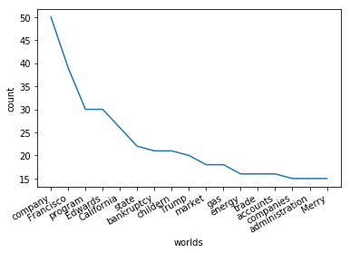

```python
%matplotlib inline
import matplotlib.pyplot as plt  # blow are the most frequent worlds with meaning
wo=["company",'Francisco','program','Edwards',"California",'state','bankruptcy','childern','Trump','market','gas','energy','trade','accounts','companies','administration','Merry']
count=[50,39,30,30,26,22,21,21,20,18,18,16,16,16,15,15,15]
fig, ax = plt.subplots() #plot
ax.plot(wo, count)
plt.xlabel('worlds')
plt.ylabel('count')
fig.autofmt_xdate()
```

```python
len(locol)                                         ###save all content in txt
txt2=locol.iloc[0,5]
for i in range(1,len(locol),1):
    txt2+=locol.iloc[i,5]
    i+=1
words2 =nltk.word_tokenize(txt2)
fq2 = nltk.FreqDist(w for w in words2)
fq2.most_common(150)                                 #show top 150 most frequent worlds
```

```
[(',', 3018),
 ('the', 2083),
 ('.', 1446),
 ('to', 1347),
 ('and', 1237),
 ('a', 1173),
 ('’', 1132),
 ('of', 1091),
 ("''", 1012),
 ('in', 838),
 ('s', 701),
 (':', 655),
 ('for', 590),
 ('“', 586),
 ('”', 580),
 ('is', 437),
 ('that', 424),
 ('on', 395),
 ('was', 366),
 ('said', 365),
 ('with', 344),
 ('San', 293),
 ('he', 291),
 ('I', 280),
 ('it', 265),
 ('Francisco', 263),
 ('at', 256),
 ('The', 251),
 ('her', 237),
 ('from', 231),
 ('she', 221),
 ('his', 218),
 ('$', 200),
 ('t', 191),
 ('have', 188),
 ('be', 188),
 ('—', 184),
 ('are', 181),
 ('who', 181),
 ('as', 173),
```

[output cut: 95 more lines]

```
 ('no', 50),
 ('A', 50),
 ('family', 49),
 ('[', 49),
 (']', 49),
 ('Fund', 48),
 ('Twitter', 47),
 ('staff', 46),
 ('still', 45),
 ('going', 45),
 ('where', 45),
 ('Breed', 45),
 ('much', 44),
 ('d', 44),
 ('helped', 43)]
```

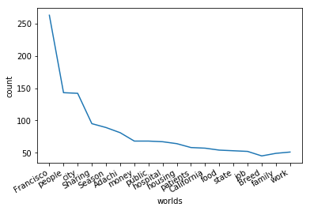

```python
# blow are the most frequent worlds with meaning
wo=['Francisco','people','city','Sharing','Season','Adachi','money','public','hospital','housing','patients','California','food','state','job','Breed','family',"work"]
count=[263,143,142,95,89,81,68,68,67,64,58,57,54,53,52,45,49,51]
fig, ax = plt.subplots() #plot
ax.plot(wo, count)
plt.xlabel('worlds')
plt.ylabel('count')
fig.autofmt_xdate()
```

```python
len(sport)                                   ###save all content in txt3
txt3=sport.iloc[0,5]
for i in range(1,len(sport),1):
    txt3+=sport.iloc[i,5]
    i+=1
words3 =nltk.word_tokenize(txt3)
fq3 = nltk.FreqDist(w for w in words3)
fq3.most_common(150)                          #show top 150 most frequent worlds
```

```
[(',', 3803),
 ('the', 2593),
 ("''", 2063),
 ('.', 1860),
 ('’', 1691),
 ('a', 1390),
 ('to', 1300),
 ('in', 1193),
 (':', 1172),
 ('and', 1163),
 ('of', 958),
 ('s', 942),
 ('“', 673),
 ('”', 635),
 ('for', 531),
 ('at', 512),
 ('on', 448),
 ('he', 443),
 ('is', 434),
 ('I', 431),
 ('that', 424),
 ('with', 392),
 ('his', 366),
 ('was', 360),
 ('(', 336),
 (')', 336),
 ('it', 333),
 ('said', 326),
 ('The', 280),
 ('as', 264),
 ('t', 250),
 ('be', 246),
 (';', 204),
 ('from', 192),
 ('have', 190),
 ('—', 186),
 ('He', 183),
 ('has', 182),
 ('who', 177),
 ('an', 177),
```

[output cut: 95 more lines]

```
 ('three', 64),
 ('good', 63),
 ('Twitter', 62),
 ('me', 62),
 ('really', 62),
 ('could', 61),
 ('win', 61),
 ('its', 61),
 ('before', 61),
 ('And', 61),
 ('‘', 60),
 ('Arizona', 59),
 ('sfchronicle.com', 59),
 ('scored', 59),
 ('school', 59)]
```

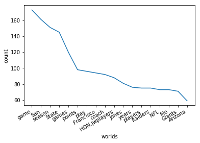

```python
# blow are the most frequent worlds with meaning
wo=['game','San','season','State','games','points','play','Francisco','coach','HDN.jwplayers','Jones','years','players','Raiders','NFL','file','Giants','Arizona']
count=[173,161,151,145,120,98,96,94,92,88,81,76,75,75,73,73,71,59]
fig, ax = plt.subplots()            #plot
ax.plot(wo, count)
plt.xlabel('worlds')
plt.ylabel('count')
fig.autofmt_xdate()
```

in business it covered "company",'Francisco','program','Edwards',"California",'state','bankruptcy','childern','Trump','market','gas','energy','trade','accounts','companies','administration','Merry'

in local it coverd 'Francisco','people','city','Sharing','Season','Adachi','money','public','hospital','housing','patients','California','food','state','job','Breed','family',"work"

in sport it coverd 'game','San','season','State','games','points','play','Francisco','coach','HDN.jwplayers','Jones','years','players','Raiders','NFL','file','Giants','Arizona'